# KMA712 - Assignment 1

Bindoff, A.

Student number 134323

2019-04-26 17:36:12

# Background

A query sequence was aligned with targets in the NCBI nucleotide database using BLAST. Neighbour joining, maximum parsimony, maximum likelihood and phylogenetic network methods were used to estimate phylogenetic relationships between 16 of the returned sequences.

# Methods and Results

This section is tabbed to aid navigation.

## BLAST

The BLASTn algorithm (Altschul et al. 1997) was used to find high-scoring segment pairs (HSP) for the nucleotide query sequence AGGTGGCTCTAGAGAATCCCCAAATGCAAAACTCAGAGATCAGCAAGCAGCTGGGGTACC… against the database maintained at [NCBI](https://blast.ncbi.nlm.nih.gov/). An API call was made initially using the R package `annotate` (Gentleman 2018), however a query using the website interface proved to be much faster. Results were saved by copying and pasting the resulting table into Excel and saving as a .csv file.

```r
#biocLite("annotate")
library(annotate)
bs <- blastSequences(sq, timeout = 480, as = "data.frame")
```

### BLAST Results

A search of the NCBI nucleotide databases suggests that the query sequence is most likely from the genome of a fur seal (sp *Arctocephalus*), encoding for sex determining region Y protein.

```r
bs <- read_csv("bs.csv")

dplyr::select(bs, Accession, Description, `E value`, `Per. Ident`, `Query Cover`) %>%
  dplyr::arrange(`E value`) %>%
  kable()
```

| Accession | Description | E value | Per. Ident | Query Cover |
| --- | --- | --- | --- | --- |
| AY429653.1 | Arctocephalus australis sex determining region Y protein (SRY) gene, complete cds | 0 | 97.19% | 99% |
| AY429652.1 | Arctocephalus forsteri sex determining region Y protein (SRY) gene, complete cds | 0 | 97.19% | 99% |
| AY424651.1 | Arctocephalus gazella sex determining region Y protein (SRY) gene, complete cds | 0 | 97.19% | 99% |
| AY424649.1 | Eumetopias jubatus sex determining region Y protein (SRY) gene, complete cds | 0 | 97.19% | 99% |
| AY424650.1 | Zalophus californianus sex determining region Y protein (SRY) gene, complete cds | 0 | 96.84% | 99% |
| XM_004417134.1 | PREDICTED: Odobenus rosmarus divergens sex determining region Y (SRY), mRNA | 0 | 96.49% | 88% |
| AY424653.1 | Odobenus rosmarus sex determining region Y protein (SRY) gene, complete cds | 0 | 96.49% | 99% |
| AY424652.1 | Callorhinus ursinus sex determining region Y protein (SRY) gene, complete cds | 0 | 96.14% | 99% |
| AY424664.1 | Phoca largha sex determining region Y protein (SRY) gene, complete cds | 0 | 94.79% | 99% |
| AY424663.1 | Phoca hispida sex determining region Y protein (SRY) gene, complete cds | 0 | 94.79% | 99% |
| AY424662.1 | Phoca vitulina sex determining region Y protein (SRY) gene, complete cds | 0 | 94.79% | 99% |
| AY424660.1 | Halichoerus grypus sex determining region Y protein (SRY) gene, complete cds | 0 | 94.79% | 99% |
| AY424661.1 | Phoca caspica sex determining region Y protein (SRY) gene, complete cds | 0 | 94.44% | 99% |
| AY424659.1 | Phoca groenlandica sex determining region Y protein (SRY) gene, complete cds | 0 | 94.44% | 99% |
| AY424658.1 | Cystophora cristata sex determining region Y protein (SRY) gene, complete cds | 0 | 94.44% | 99% |
| KY608944.1 | Leptonychotes weddellii isolate M03 sex-determining region Y protein (SRY) gene, partial cds | 0 | 94.43% | 79% |
| KY608943.1 | Leptonychotes weddellii isolate K74 sex-determining region Y protein (SRY) gene, partial cds | 0 | 94.43% | 79% |
| KY608942.1 | Leptonychotes weddellii isolate K73 sex-determining region Y protein (SRY) gene, partial cds | 0 | 94.43% | 79% |
| KY608941.1 | Leptonychotes weddellii isolate K69 sex-determining region Y protein (SRY) gene, partial cds | 0 | 94.43% | 79% |
| KY608940.1 | Leptonychotes weddellii isolate K67 sex-determining region Y protein (SRY) gene, partial cds | 0 | 94.43% | 79% |
| KY608939.1 | Leptonychotes weddellii isolate K59 sex-determining region Y protein (SRY) gene, partial cds | 0 | 94.43% | 79% |
| KY608938.1 | Leptonychotes weddellii isolate K51 sex-determining region Y protein (SRY) gene, partial cds | 0 | 94.43% | 79% |
| KY608937.1 | Leptonychotes weddellii isolate K49 sex-determining region Y protein (SRY) gene, partial cds | 0 | 94.43% | 79% |
| KY608936.1 | Leptonychotes weddellii isolate K48 sex-determining region Y protein (SRY) gene, partial cds | 0 | 94.43% | 79% |
| KY608934.1 | Leptonychotes weddellii isolate K45 sex-determining region Y protein (SRY) gene, partial cds | 0 | 94.43% | 79% |
| KY608933.1 | Leptonychotes weddellii isolate K43 sex-determining region Y protein (SRY) gene, partial cds | 0 | 94.43% | 79% |
| KY608932.1 | Leptonychotes weddellii isolate K38 sex-determining region Y protein (SRY) gene, partial cds | 0 | 94.43% | 79% |
| KY608931.1 | Leptonychotes weddellii isolate K34 sex-determining region Y protein (SRY) gene, partial cds | 0 | 94.43% | 79% |
| KY608930.1 | Leptonychotes weddellii isolate K29 sex-determining region Y protein (SRY) gene, partial cds | 0 | 94.43% | 79% |
| KY608929.1 | Leptonychotes weddellii isolate K28 sex-determining region Y protein (SRY) gene, partial cds | 0 | 94.43% | 79% |

[output cut: 70 more lines]

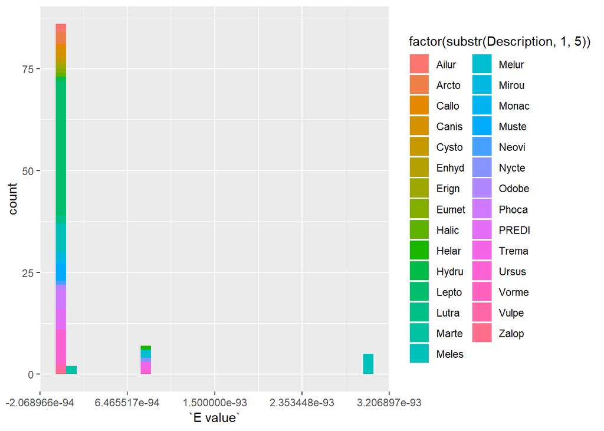

```r
ggplot(bs, aes(x = `E value`, fill = factor(substr(Description, 1, 5)))) +
  geom_histogram()
```

### Query cover

Query cover is the proportion of characters of the query sequence that are included in the [aligned] target sequence (x100).

### Percent identity

Percent identity describes the proportion of characters in the query sequence that match the target sequence (x100), such that identical sequences will have a percent identity of 100% and sequences with no matching characters will have a percent identity of 0%.

This number is not adjusted for the length of the query or target sequences, nor does it take into account the probability of matching by chance.

### *E*-value

#### Pairwise *E*-value

Consider the comparison of two sequences. Interest lies in determining whether there is evidence of shared ancestry (homology) between the sequences. A local alignment comprises an equal length segment from each sequence. Sufficient similarity between the aligned segments may be evidence of homology. However similarity can occur by chance so it is helpful to estimate the likelihood of observing the alignment by chance alone, using a model of random sequences (Altschul et al. 1990).

For sufficiently large random sequences of lengths $m$ and $n$, the expected number (*E*-value) of local alignments with score at least $S$ is given by

$$E \approx K mn e^{-\lambda S}$$

where $K$ and $\lambda$ are natural scales for the search space size and the scoring system respectively (Altschul et al. 1990). Thus, *E*-value gives a better measure of the **significance** of a match between query and target sequence than percent identity, as it makes a correction for the search space.

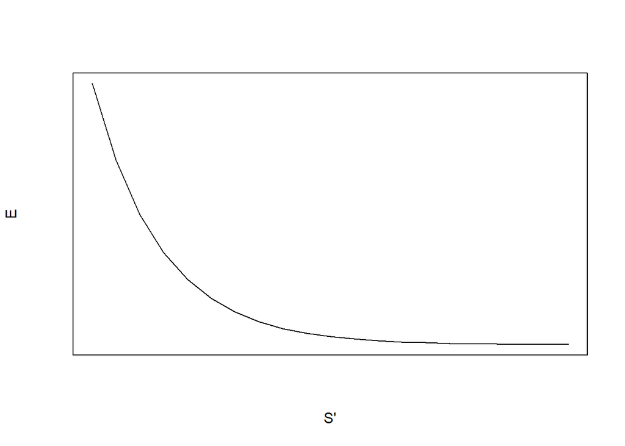

The probability of finding exactly $z$ HSPs with score $\geq S$ is Poisson distributed
$$e^{-E} {E^z \over z!}$$

because the probability of finding $z = 0$ HSPs with score $\geq S$ is $e^{-E}$, the probability of finding at least one HSP with score $\geq S$ is
$$P = 1- e^{-E}$$

For small $E$, *P*-values and *E*-values are approximately equivalent. *E*-values are reported in BLAST results because they are intuitively easier to grasp.

#### Database *E*-values

NCBI BLAST treats the database of sequences as a single very long sequence of length $N$, and calculate *E*-values using this in the place of $n$ in the above equation. **Thus, the *E*-values reported in the table above describe how many times you would expect a match by chance in a database containing all of the nucleotide sequences stored in the NCBI database.**

## Alignment

16 sequences were chosen from different species and downloaded. They were then aligned using clustal omega (Sievers and Higgins 2014) and also with muscle (Edgar 2004) in Seaview (Gouy, Guindon, and Gascuel 2009). Both alignments looked plausible, starting identically up to about 80 base-pairs.

```r
aligned <- bio3d::read.fasta("fasta_15.fst")
print.fasta(aligned)
```

```
##              1        .         .         .         .         .         60
## AY429653.1   ------------------------------------------------------------
## AY429652.1   ------------------------------------------------------------
## AY424651.1   -----------------------------------------TTTAAAGTTTGTTTTTTAA
## AY424649.1   -----------------------------------------TTTAAAGTTTGTTTTTTAA
## AY424650.1   -----------------------------------------TTTAAAGTTTGTTTTTTAA
## AY424663.1   -----------------------------------------TTTAAAGTTTGTTTTTTAA
## AY424658.1   -----------------------------------------TTTAAAGTTTGTTTCTTAA
## KY608941.1   ------------------------------------------------------------
## AY424657.1   -----------------------------------------TTTAAAGTTTGTTTTTTAA
## AY424655.1   -----------------------------------------TTTAAAGTTTGTTTTTTAA
## AB292070.1   --------------------AGCTAGTAGAATTACATTATCTTTAAAGTTTGTTTTTTAA
## AB491590.1   ------------------------------------------------------------
## EU371738.1   ------------------------------------------------------------
## AM748311.1   -------------TTTTAATAGCTAGTAGAATTACATTATCTTTAAAGTTTGTTTTTTAA
## AY424666.1   GTATCCAGTGGTGTTTTAATAGCTAGTAGAATTACATTATCTTTAAGGTTTGTTTTTTAA
## AB539128.1   ------------------------------------------------------------
##
##              1        .         .         .         .         .         60
##
##             61        .         .         .         .         .         120
## AY429653.1   ------------------------------------------------------------
## AY429652.1   ------------------------------------------------------------
## AY424651.1   ACG-TAAATTTCACTTTTGATAAACAATTCACAATCTTTCCTGCACATTCCTCCTTTGAT
## AY424649.1   ATG-TAAATTTCACTTTTGATAAACAATTCACAATCTTTCCTGCACCTTCCTCCTTTGAT
## AY424650.1   ACG-TAAATTTCACTTTTGATAAACAATTCACAATCTTTCCTGCACATTCCTCCTTTGAT
## AY424663.1   ACG-TAACTTTCACTTTTGATAAGCAATTCACAATCTTTCCTACACATTCCTCCTTT-AT
## AY424658.1   ACG-TAACTTTCACTTTTGATAAGCAATTCCCAATCTTTCCTACACATTCCTCCTTT-AT
## KY608941.1   ------------------------------------------------------------
## AY424657.1   ACG-TAACTTTCACTTTTGATAAACAATTCACAGTCTTTCCTGCACATTCCTCCTTTGAT
## AY424655.1   ACG-TAACTTTCACTTTTGATAAGCAATTCACAGTCTTTCCTGCACATTCCTCCTTTGAT
## AB292070.1   ACATTAACTTTCACTTTTGATAAACAATTTGCAATCTTTGCTGCACAGTCCTCCTTTGAT
## AB491590.1   ------------------------------------------------------------
## EU371738.1   ------------------------------------------------------------
## AM748311.1   ACA-TAACTTTCACTTTTGATAAACAATTTGCAGTCTTTGCTGCACATTCCTCCTTTGAT
## AY424666.1   ACA-TAACTTTCACTTTTGATAAACAATTTGCAATCTTTGCTGCACATTCCTCCTTTGAT
## AB539128.1   ------------------------------------------------------------
##
##             61        .         .         .         .         .         120
##
```

[output cut: 415 more lines]

```
## AY424666.1   GTCTGGGTTTATGGCTGC-----------------------------
## AB539128.1   -----------------------------------------------
##
##           1321        .         .         .         .      1367
##
## Call:
##   bio3d::read.fasta(file = "fasta_15.fst")
##
## Class:
##   fasta
##
## Alignment dimensions:
##   16 sequence rows; 1367 position columns (618 non-gap, 749 gap)
##
## + attr: id, ali, call
```

## Neighbour Joining

SplitsTree4 (Huson and Bryant 2005) was used to build neighbour-joining trees, using 1000 bootstrap replicates to estimate robustness of the tree.

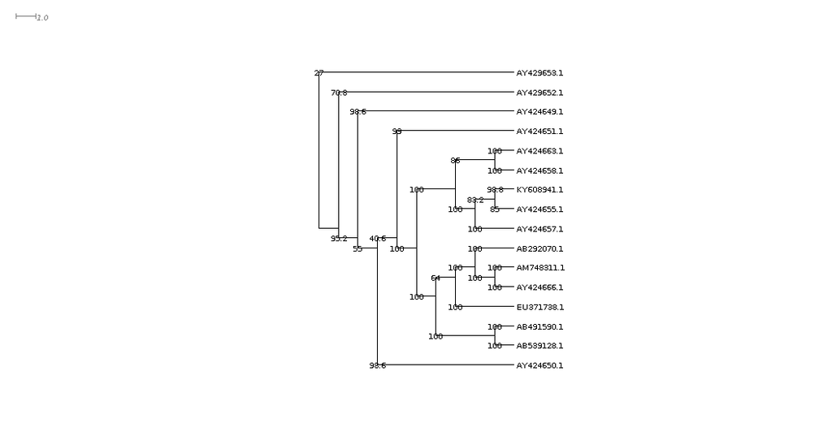

Neighbour joining tree with bootstrap estimates

## Maximum Parsimony Tree

PHYLIP v3.696 (Felsenstein 2004) was used to compute parsimony trees in SeaView (Gouy, Guindon, and Gascuel 2009).

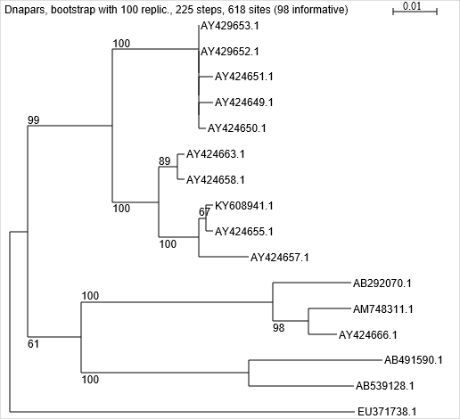

Parsimony tree with bootstrap estimates